# Social Network Data (Collaborative Filtering)

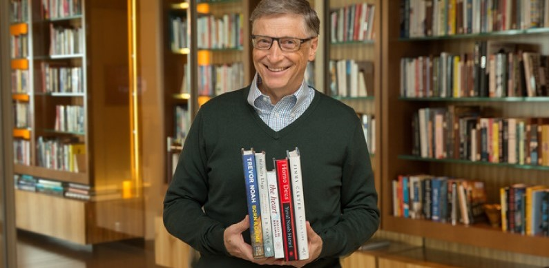

.................................................... start of document ....................................................

## Synopsis

**Terms**

- **Recommender System**
- **Bipartite Graph or Bigraph**
- **Collaborative Filtering**
  - **Neighborhood Approach**
    - **User-Based:** predict a user's preference for an item based on ratings for that item by similar users
    - **Item-Based:** predict a user's preference for an item based on ratings of similar items by that user
  - **Latent Factor Approach:** characterize both users and items in terms of variables inferred from user ratings

## Exposition

### Data

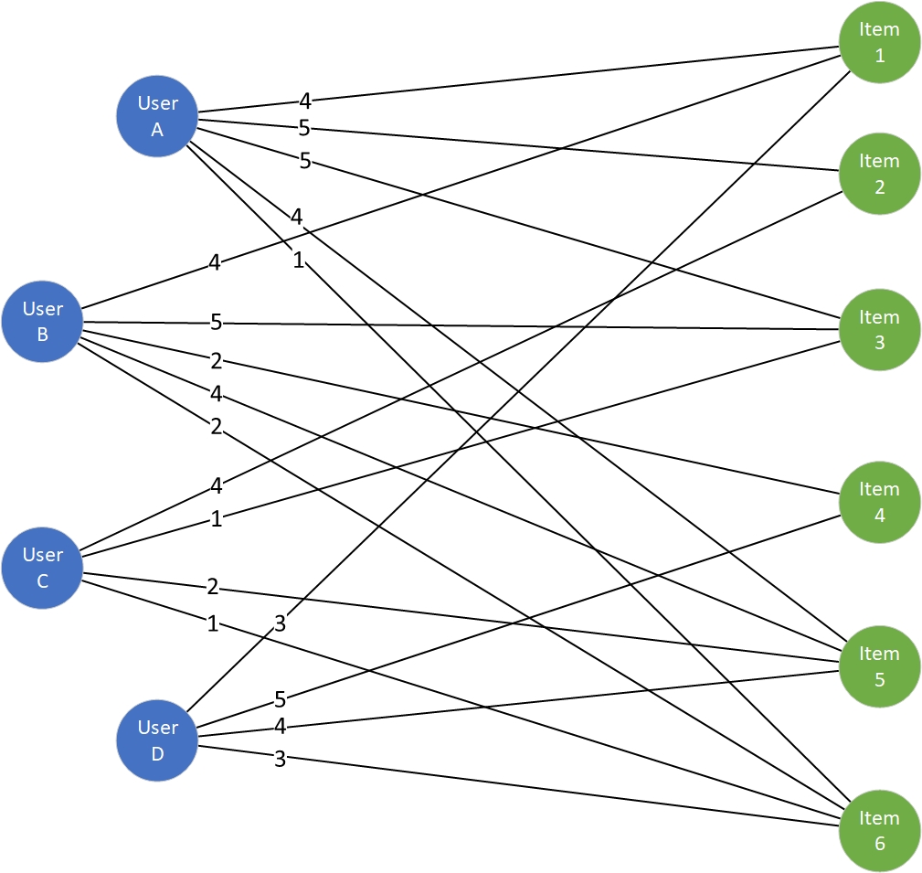

**data (adjacency matrix)**

|  | user_a | user_b | user_c | user_d | item_1 | item_2 | item_3 | item_4 | item_5 | item_6 |
| --- | --- | --- | --- | --- | --- | --- | --- | --- | --- | --- |
| user_a | 0 | 0 | 0 | 0 | 1 | 1 | 1 | 0 | 1 | 1 |
| user_b | 0 | 0 | 0 | 0 | 1 | 0 | 1 | 1 | 1 | 1 |
| user_c | 0 | 0 | 0 | 0 | 0 | 1 | 1 | 0 | 1 | 1 |
| user_d | 0 | 0 | 0 | 0 | 1 | 0 | 0 | 1 | 1 | 1 |
| item_1 | 0 | 0 | 0 | 0 | 0 | 0 | 0 | 0 | 0 | 0 |
| item_2 | 0 | 0 | 0 | 0 | 0 | 0 | 0 | 0 | 0 | 0 |
| item_3 | 0 | 0 | 0 | 0 | 0 | 0 | 0 | 0 | 0 | 0 |
| item_4 | 0 | 0 | 0 | 0 | 0 | 0 | 0 | 0 | 0 | 0 |
| item_5 | 0 | 0 | 0 | 0 | 0 | 0 | 0 | 0 | 0 | 0 |
| item_6 | 0 | 0 | 0 | 0 | 0 | 0 | 0 | 0 | 0 | 0 |

**data**

|  | item_1 | item_2 | item_3 | item_4 | item_5 | item_6 |
| --- | --- | --- | --- | --- | --- | --- |
| user_a | 4 | 5 | 5 | NA | 4 | 1 |
| user_b | 4 | NA | 5 | 2 | 4 | 2 |
| user_c | NA | 4 | 1 | NA | 2 | 1 |
| user_d | 3 | NA | NA | 5 | 4 | 3 |

### Collaborative Filtering

Neighborhood approach, user-based. Predict ratings of would-be links. Assume that similar users rate a particular item similarly.

#### Simple Version

- Use only the rating of the most similar user
- Measure similarity by correlation
- Disregard missing data, treat negative correlations as no similarity

Specifically, predictions for ratings are calculated like this:

$ \begin{align} \hat{r}_{u,i} = r_{x,i} \end{align} $

where ...

- $\hat{r}_{u,i}$ is the prediction for user $u$'s rating of item $i$
- $x$ is the index of the user most similar to user $u$
- $r_{x,i}$ is user $x$'s rating of item $i$

**data (transposed)**

|  | user_a | user_b | user_c | user_d |
| --- | --- | --- | --- | --- |
| item_1 | 4 | 4 | NA | 3 |
| item_2 | 5 | NA | 4 | NA |
| item_3 | 5 | 5 | 1 | NA |
| item_4 | NA | 2 | NA | 5 |
| item_5 | 4 | 4 | 2 | 4 |
| item_6 | 1 | 2 | 1 | 3 |

**similarity matrix (correlation after negatives removed)**

|  | user_a | user_b | user_c | user_d |
| --- | --- | --- | --- | --- |
| user_a | 1.0000000 | 0.9941348 | 0.4980582 | 0.5 |
| user_b | 0.9941348 | 1.0000000 | 0.1889822 | 0.0 |
| user_c | 0.4980582 | 0.1889822 | 1.0000000 | 1.0 |
| user_d | 0.5000000 | 0.0000000 | 1.0000000 | 1.0 |

**Predict User A's rating of Item 4:**

**prediction**

| user | similar_user | item_4 |
| --- | --- | --- |
| user_a | user_b | 2 |

**data (after filtered just for user_a)**

|  | item_1 | item_2 | item_3 | item_4 | item_5 | item_6 |
| --- | --- | --- | --- | --- | --- | --- |
| user_a | 4 | 5 | 5 | 2 | 4 | 1 |
| user_b | 4 | NA | 5 | 2 | 4 | 2 |
| user_c | NA | 4 | 1 | NA | 2 | 1 |
| user_d | 3 | NA | NA | 5 | 4 | 3 |

**Predict all missing ratings:**

**similar user rating**

| user | similar_user | item_1 | item_2 | item_3 | item_4 | item_5 | item_6 |
| --- | --- | --- | --- | --- | --- | --- | --- |
| user_a | user_b | 4 | NA | 5 | 2 | 4 | 2 |
| user_b | user_a | 4 | 5 | 5 | NA | 4 | 1 |
| user_c | user_d | 3 | NA | NA | 5 | 4 | 3 |
| user_d | user_c | NA | 4 | 1 | NA | 2 | 1 |

**data (after filtered)**

|  | item_1 | item_2 | item_3 | item_4 | item_5 | item_6 |
| --- | --- | --- | --- | --- | --- | --- |
| user_a | 4 | 5 | 5 | 2 | 4 | 1 |
| user_b | 4 | 5 | 5 | 2 | 4 | 2 |
| user_c | 3 | 4 | 1 | 5 | 2 | 1 |
| user_d | 3 | 4 | 1 | 5 | 4 | 3 |

#### Weighted Version

- Use ratings of all other users, adjusted by similarity
- Measure similarity by correlation
- Disregard missing data, treat negative correlations as no similarity

Specifically, predictions for ratings are calculated like this:

$ \begin{align} \hat{r}_{u,i} = \frac{\sum_{x \in N_u}{w_{x,u} r_{x,i}}}{\sum_{x \in N_u}{w_{x,u}}} \end{align} $

where ...

- $\hat{r}_{u,i}$ is the prediction for user $u$'s rating of item $i$
- $N_u$ are the indices of the users other than user $u$
- $w_{x,u}$ is the measure of how similar user $x$ is to user $u$
- $r_{x,i}$ is user $x$'s rating of item $i$

**Calculate similarity matrix:**

**data (transposed)**

|  | user_a | user_b | user_c | user_d |
| --- | --- | --- | --- | --- |
| item_1 | 4 | 4 | NA | 3 |
| item_2 | 5 | NA | 4 | NA |
| item_3 | 5 | 5 | 1 | NA |
| item_4 | NA | 2 | NA | 5 |
| item_5 | 4 | 4 | 2 | 4 |
| item_6 | 1 | 2 | 1 | 3 |

**similarity matrix (correlation after negatives removed)**

|  | user_a | user_b | user_c | user_d |
| --- | --- | --- | --- | --- |
| user_a | 1.0000000 | 0.9941348 | 0.4980582 | 0.5 |
| user_b | 0.9941348 | 1.0000000 | 0.1889822 | 0.0 |
| user_c | 0.4980582 | 0.1889822 | 1.0000000 | 1.0 |
| user_d | 0.5000000 | 0.0000000 | 1.0000000 | 1.0 |

**Predict User A's rating of Item 4:**  
Prediction is weighted mean of ratings, where weights are similarity measures and missing data are ignored.

**calculation for user_a rating of item_4**

| user | weight | rating | contribution_to_weighted_mean |
| --- | --- | --- | --- |
| user_b | 0.9941348 | 2 | 1.98827 |
| user_c | 0.4980582 | NA | NA |
| user_d | 0.5000000 | 5 | 2.50000 |

**prediction**

| user | item_4 |
| --- | --- |
| user_a | 3.003925 |

**data (after filtered just for user_a)**

|  | item_1 | item_2 | item_3 | item_4 | item_5 | item_6 |
| --- | --- | --- | --- | --- | --- | --- |
| user_a | 4 | 5 | 5 | 3.003925 | 4 | 1 |
| user_b | 4 | NA | 5 | 2.000000 | 4 | 2 |
| user_c | NA | 4 | 1 | NA | 2 | 1 |
| user_d | 3 | NA | NA | 5.000000 | 4 | 3 |

**Predict all missing ratings:**

**prediction**

| user | item_1 | item_2 | item_3 | item_4 | item_5 | item_6 |
| --- | --- | --- | --- | --- | --- | --- |
| user_a | 3.665358 | 4.000000 | 3.664896 | 3.003925 | 3.499990 | 2.000975 |
| user_b | 4.000000 | 4.840268 | 4.361070 | NaN | 3.680535 | 1.000000 |
| user_c | 3.407246 | 5.000000 | 5.000000 | 4.523166 | 4.000000 | 2.297528 |
| user_d | 4.000000 | 4.333333 | 2.333333 | NaN | 2.666667 | 1.000000 |

**data (after filtered)**

|  | item_1 | item_2 | item_3 | item_4 | item_5 | item_6 |
| --- | --- | --- | --- | --- | --- | --- |
| user_a | 4.000000 | 5.000000 | 5.000000 | 3.003925 | 4 | 1 |
| user_b | 4.000000 | 4.840268 | 5.000000 | 2.000000 | 4 | 2 |
| user_c | 3.407246 | 4.000000 | 1.000000 | 4.523166 | 2 | 1 |
| user_d | 3.000000 | 4.333333 | 2.333333 | 5.000000 | 4 | 3 |

#### Adjusted Weighted Version

- Calibrate to account for differences in users' average ratings
- Use ratings of only some other users, adjusted by similarity
- Measure similarity by correlation
- Disregard missing data, treat negative correlations as no similarity

Specifically, predictions for ratings are calculated like this:

$ \begin{align} \hat{r}_{u,i} = \bar{r}_u + \alpha \frac{\sum_{x \in N^t_u}{w_{x,u} (r_{x,i} - \bar{r}_x)}}{\sum_{x \in N^t_u}{w_{x,u}}} \end{align} $

where ...

- $\hat{r}_{u,i}$ is the prediction for user $u$'s rating of item $i$
- $\bar{r}_u$ is the average of user $u$'s ratings for all items
- $\bar{r}_x$ is the average of user $x$'s ratings for all items
- $\alpha$ is a parameter indicating how much a user's rating is affected by other users' ratings
- $N^t_u$ are the indices of the users most similar to user $u$ (a threshold parameter $t$ sets the number of similar users to use)
- $w_{x,u}$ is the measure of how similar user $x$ is to user $u$
- $r_{x,i}$ is user $x$'s rating of item $i$

**Set parameters:**

| threshold | alpha |
| --- | --- |
| 2 | 1 |

**Calculate similarity matrix:**

**data (transposed)**

|  | user_a | user_b | user_c | user_d |
| --- | --- | --- | --- | --- |
| item_1 | 4 | 4 | NA | 3 |
| item_2 | 5 | NA | 4 | NA |
| item_3 | 5 | 5 | 1 | NA |
| item_4 | NA | 2 | NA | 5 |
| item_5 | 4 | 4 | 2 | 4 |
| item_6 | 1 | 2 | 1 | 3 |

**similarity matrix (correlation after negatives removed)**

|  | user_a | user_b | user_c | user_d |
| --- | --- | --- | --- | --- |
| user_a | 1.0000000 | 0.9941348 | 0.4980582 | 0.5 |
| user_b | 0.9941348 | 1.0000000 | 0.1889822 | 0.0 |
| user_c | 0.4980582 | 0.1889822 | 1.0000000 | 1.0 |
| user_d | 0.5000000 | 0.0000000 | 1.0000000 | 1.0 |

**Predict User A's rating of Item 4:**

**nearest neighbors**

|  | item_1 | item_2 | item_3 | item_4 | item_5 | item_6 |
| --- | --- | --- | --- | --- | --- | --- |
| user_b | 4 | NA | 5 | 2 | 4 | 2 |
| user_d | 3 | NA | NA | 5 | 4 | 3 |

**calculation for user_a rating of item_4**

|  | weight | rating | mean_rating.nn | diff | contribution_to_weighted_mean |
| --- | --- | --- | --- | --- | --- |
| user_b | 0.9941348 | 2 | 3.40 | -1.40 | -1.391789 |
| user_d | 0.5000000 | 5 | 3.75 | 1.25 | 0.625000 |

**prediction**

|  | mean_rating | alpha | weighted_mean_part | item_4 |
| --- | --- | --- | --- | --- |
| user_a | 3.8 | 1 | -0.5131992 | 3.286801 |

**data (after filtered just for user_a)**

|  | item_1 | item_2 | item_3 | item_4 | item_5 | item_6 |
| --- | --- | --- | --- | --- | --- | --- |
| user_a | 4 | 5 | 5 | 3.286801 | 4 | 1 |
| user_b | 4 | NA | 5 | 2.000000 | 4 | 2 |
| user_c | NA | 4 | 1 | NA | 2 | 1 |
| user_d | 3 | NA | NA | 5.000000 | 4 | 3 |

**Predict all missing ratings:**

**prediction**

|  | item_1 | item_2 | item_3 | item_4 | item_5 | item_6 |
| --- | --- | --- | --- | --- | --- | --- |
| user_a | 3.948234 | NaN | 5.400000 | 3.286801 | 4.282875 | 2.6175172 |
| user_b | 3.600000 | 4.727786 | 4.248589 | NaN | 3.568053 | 0.8875185 |
| user_c | 1.565846 | 3.200000 | 3.200000 | 3.250000 | 2.233376 | 0.5684381 |
| user_d | 3.950000 | 5.483333 | 3.483333 | NaN | 3.816667 | 2.1500000 |

**data (after filtered)**

|  | item_1 | item_2 | item_3 | item_4 | item_5 | item_6 |
| --- | --- | --- | --- | --- | --- | --- |
| user_a | 4.000000 | 5.000000 | 5.000000 | 3.286801 | 4 | 1 |
| user_b | 4.000000 | 4.727786 | 5.000000 | 2.000000 | 4 | 2 |
| user_c | 1.565846 | 4.000000 | 1.000000 | 3.250000 | 2 | 1 |
| user_d | 3.000000 | 5.483333 | 3.483333 | 5.000000 | 4 | 3 |

Copyright (c) Berkeley Data Analytics Group, LLC Document revised December 5, 2019